# **BDA-503 Week 5 - Izmir Fish Market Assignment**

Emirhan Şahin

December 14, 2021

# **Izmir Fish Market 2021 Daily Prices**

In this assignment, we will go into the details of the CSV file that is obtained by Izmir Metropolitan Municipality’s **[Open Data website.](https://acikveri.bizizmir.com/tr/dataset/balik-hal-fiyatlari)**

**[The data](https://openfiles.izmir.bel.tr/100160/docs/balik_hal_fiyatlari.csv)** in the link has already loaded as seen below, also necessary packages in the background, let’s get on to the analyzes and reports of the data.

```r
df <- read_delim("balik_hal_fiyatlari.csv", delim = ";")
```

### **1-) Structure of the Data**

Let’s see the structure of the data frame `balik_hal_fiyatlari.csv`.

```r
str(df)
```

```
spec_tbl_df [18,369 x 6] (S3: spec_tbl_df/tbl_df/tbl/data.frame)
 $ TARIH       : POSIXct[1:18369], format: "2021-01-02" "2021-01-02" ...
 $ MAL_TURU    : chr [1:18369] "BALIK" "BALIK" "BALIK" "BALIK" ...
 $ MAL_ADI     : chr [1:18369] "TIRSI (DENIZ)" "KIRLANGIÇ (DENIZ)" "ÇIMÇIM (DENIZ)" "HANOS ( DENIZ )" ...
 $ BIRIM       : chr [1:18369] "KG" "KG" "KG" "KG" ...
 $ ASGARI_UCRET: num [1:18369] 5.83 3 3.5 2.5 45 130 38 25 10 2.5 ...
 $ AZAMI_UCRET : num [1:18369] 12.5 80 8 5 45 130 38 55 10 6.67 ...
 - attr(*, "spec")=
  .. cols(
  ..   TARIH = col_datetime(format = ""),
  ..   MAL_TURU = col_character(),
  ..   MAL_ADI = col_character(),
  ..   BIRIM = col_character(),
  ..   ASGARI_UCRET = col_double(),
  ..   AZAMI_UCRET = col_double()
  .. )
 - attr(*, "problems")=<externalptr>
```

We see that there is 18,369 observations which are seperated by 6 different columns. First **“TARIH”** column is a date format, **“MAL_TURU”**, **“MAL_ADI”** and **“BIRIM”** columns are characters and last two **“ASGARI_UCRET”** and **“AZAMI_UCRET”** columns are numbers.

### **2-) Most 5 Expensive Fishes and its Maximum Price in 2021**

As you can see in the below code the most 5 expensive fishes are **Barbun, Istakoz, Levrek, Mercan and Peygamber.**

```r
max_prices <- df %>%
  group_by(MAL_ADI, BIRIM) %>%
  summarise(MAX_PRICE = max(AZAMI_UCRET)) %>%
  arrange(desc(MAX_PRICE)) %>%
  head(5) %>%
  ungroup()
max_prices
```

| MAL_ADI | BIRIM | MAX_PRICE |
| --- | --- | --- |
| BARBUN (TEKIR) | KG | 3500 |
| ISTAKOZ (DENIZ) | KG | 750 |
| LEVREK (DENIZ) | KG | 500 |
| MERCAN (BÜYÜKBOY) | KG | 500 |
| PEYGAMBER (DENIZ) | KG | 500 |

### **3-) Average Maximum Prices of Freshwater Fishes**

The code below demonstrates the average maximum price of freshwater fishes in 2021.

```r
freshwater_fish <- df %>%
  filter(MAL_TURU == "TATLI SU") %>%
  group_by(MAL_ADI, BIRIM) %>%
  summarise(AVG_MAX_PRICE = mean(AZAMI_UCRET)) %>%
  arrange(desc(AVG_MAX_PRICE)) %>%
  ungroup()
freshwater_fish
```

| MAL_ADI | BIRIM | AVG_MAX_PRICE |
| --- | --- | --- |
| ITHAL SOMON(TATLI) | KG | 70.038793 |
| SOMON ( TATLI ) | KG | 47.478947 |
| ALABALIK(DONUK) | KG | 32.000000 |
| ALABALIK ( TATLI ) | KG | 27.843056 |
| TURNA ( TATLI ) | KG | 21.800000 |
| SUDAK ( TATLI ) | KG | 20.000000 |
| YAYIN ( TATLI ) | KG | 18.860000 |
| SAZAN ( TATLI ) | KG | 18.754011 |
| YILAN ( TATLI ) | KG | 16.837607 |
| ÇAPAK(TATLI) | KG | 7.080000 |

[output cut: 1 more lines]

As seen above we see there are 11 different fish types in the Izmir fish market which are **Imported and Regular Salmon, Frozen and Regular Trout, Jack, Zander, Catfish, Carp, Eel, Bream and Hardyhead**, in order of average prices.

### **4-) Finding the Outliers and Removing Them**

For starters, we have to decide how we are going to detect the outliers. I have chosen to locate outliers with [the IQR method](https://www.statisticshowto.com/probability-and-statistics/interquartile-range/).

As seen below, I reverse engineered the original IQR method then used the [filter function](https://www.rdocumentation.org/packages/dplyr/versions/0.7.8/topics/filter) to demonstrate the outliers.

```r
df_outliers <- df %>%
  group_by(MAL_ADI) %>%
  transmute(AZAMI_UCRET, ASGARI_UCRET, FARK = AZAMI_UCRET - ASGARI_UCRET,
            IQR_FARK = IQR(FARK),
            UPPER = quantile(FARK, 0.75) + IQR_FARK * 1.5,
            LOWER = quantile(FARK, 0.25) - IQR_FARK * 1.5) %>%
  filter(!(FARK <= UPPER & FARK >= LOWER))
df_outliers
```

| MAL_ADI | AZAMI_UCRET | ASGARI_UCRET | FARK | IQR_FARK | UPPER | LOWER |
| --- | --- | --- | --- | --- | --- | --- |
| BAKALYAR(BÜYÜKBOY) | 90.00 | 10.00 | 80.00 | 17.0000 | 65.50000 | -2.50000 |
| ÇAPAK(TATLI) | 30.00 | 5.00 | 25.00 | 1.0000 | 2.50000 | -1.50000 |
| DIL(CANGIDEZ) | 100.00 | 2.00 | 98.00 | 13.0000 | 34.50000 | -17.50000 |
| BAKALYARO(KÜÇÜKBOY) | 15.00 | 4.00 | 11.00 | 2.6000 | 10.50000 | 0.10000 |
| GRANYOZ (DENIZ) | 350.00 | 20.00 | 330.00 | 14.0000 | 52.00000 | -4.00000 |
| KÖPEK (DENIZ) | 50.00 | 8.00 | 42.00 | 8.0000 | 20.00000 | -12.00000 |
| KOFANA ( DENIZ ) | 90.00 | 15.00 | 75.00 | 20.0000 | 50.00000 | -30.00000 |
| ÇIMÇIM (DENIZ) | 35.00 | 3.00 | 32.00 | 6.0000 | 26.00000 | 2.00000 |
| ALABALIK ( TATLI ) | 31.25 | 16.25 | 15.00 | 4.8125 | 12.03125 | -7.21875 |
| ITHAL SOMON(TATLI) | 60.00 | 27.00 | 33.00 | 6.0000 | 15.00000 | -9.00000 |

[output cut: 833 more lines]

The code below demonstrates how I grouped and filtered the original data. Then instead of adjusting it, I created a new data frame called `df_no_outlier` which will be used in other calculations. I also used ungroup function so the new data frame is almost the same as the original data frame. The only difference is the outliers.

```r
df_no_outlier <- df %>%
  group_by(MAL_ADI) %>%
  mutate(FARK = AZAMI_UCRET - ASGARI_UCRET,
         IQR_FARK = IQR(FARK),
         UPPER = quantile(FARK, 0.75) + IQR_FARK * 1.5,
         LOWER = quantile(FARK, 0.25) - IQR_FARK * 1.5) %>%
  filter(FARK <= UPPER & FARK >= LOWER) %>%
  ungroup()
```

### **5-) Daily Maximum Price Difference in 2 Periods**

In this part of the code, I separated the data into two, depending on the dates that fishing was banned throughout the country and not banned. `yasak_fark` demonstrates the maximum difference in daily prices during the ban period. `serbest_fark` does the same but during the times that fishing was not banned.

```r
yasak_fark <- df_no_outlier %>%
  filter(TARIH >= "2021-04-15" & TARIH <= "2021-08-31") %>%
  group_by(MAL_ADI) %>%
  summarise(FARK = max(AZAMI_UCRET - ASGARI_UCRET))
serbest_fark <- df_no_outlier %>%
  filter(!(TARIH >= "2021-04-15" & TARIH <= "2021-08-31")) %>%
  group_by(MAL_ADI) %>%
  summarise(FARK = max(AZAMI_UCRET - ASGARI_UCRET))
```

### **6-) Visualization of the Differences between 2 Periods**

In the code below I joined two data frames in order to get the compare the differences in different periods.

```r
farklar <- serbest_fark %>%
  inner_join(yasak_fark, by = "MAL_ADI", suffix = c("_SERBEST", "_YASAK")) %>%
  mutate(DONEM_FARK = FARK_SERBEST - FARK_YASAK) %>%
  arrange(desc(DONEM_FARK))
```

Just for the hardware’s sake, I only took the differences in the head and the tail of the data frame.

```r
first_n_last <- bind_rows(head(farklar), tail(farklar)) %>%
  mutate(MAL_ADI = fct_reorder(MAL_ADI, DONEM_FARK))
```

This code below is used to create a horizontal barplot.

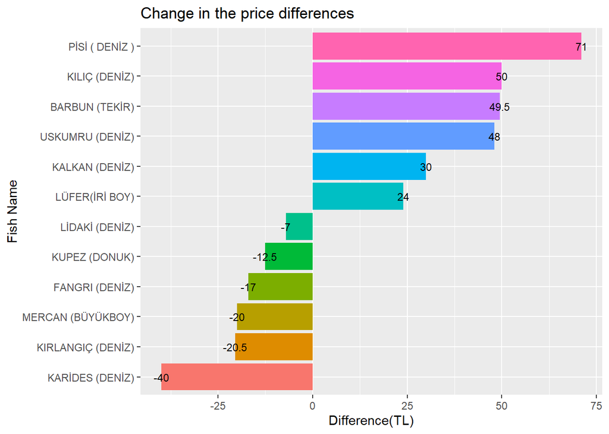

```r
ggplot(first_n_last, aes(x = MAL_ADI, y = DONEM_FARK, fill = MAL_ADI)) +
  geom_col() +
  geom_text(aes(label=DONEM_FARK), size = 3) +
  coord_flip() +
  ggtitle("Change in the price differences") +
  xlab("Fish Name") + ylab("Difference(TL)") +
  theme(legend.position = "none")
```

As seen above after eliminating the outliers which probably were a result of manipulation of the fish market or temporary occasions, we can clearly see the change in the prices of the same fish.

*Thanks for reading…*